# Analysis 1 with cross-validation: which measures predict name-sharing?

This notebook reports the cross-validated version of Analysis 1. It reads the cached results written by `cv_analyses/run_cv.R` and does no model fitting itself. See `cv_analyses/README.md` for the design.

```r
library(tidyverse)
library(here)
library(knitr)
library(kableExtra)

out_dir <- here("cv_analyses", "output")
source(here("cv_analyses", "cv_functions.R"))

lang_order <- c(languages, "All")
model_order <- names(models)
contrast_order <- names(contrasts)

insample <- read.csv(file.path(out_dir, "in_sample.csv"))
cv <- readRDS(file.path(out_dir, "cv_species.rds"))
lolo <- readRDS(file.path(out_dir, "cv_lolo.rds"))
run_info <- readLines(file.path(out_dir, "run_info.txt"))

cv_sum <- summarise_cv(cv)
cv_con <- summarise_contrasts(cv)
lolo_con <- bind_rows(summarise_lolo_contrasts(lolo, "ll_pop"),
                      summarise_lolo_contrasts(lolo, "ll_recal"))

n_reps <- n_distinct(cv$rep)
```

Settings: K 10, R 50, seed 302.

# 1. Species held out, within each language

For each language, species were split at random into 10 folds. Each model was fitted to the pairs in which neither species was in the held-out fold, and scored on the pairs in which at least one was. Every pair is scored once, so the summed held-out log-likelihood (LL) is on the same scale as the in-sample LL. This was repeated with 50 random fold splits. The “All” column is a pooled model with a separate intercept per language and common slopes.

## Held-out deviance compared with in-sample BIC

Each cell shows the held-out deviance difference from the best model, ΔDev = 2 × (LL<sub>best</sub> − LL<sub>model</sub>), averaged over splits. Below it, in brackets, is the in-sample ΔBIC from Table 2 of the paper. Both are 0 for the best model, and both are on the deviance scale. ΔBIC adds a penalty for each extra parameter, while ΔDev penalises overfitting by testing on held-out pairs.

```r
ddev_tab <- cv_sum %>%
  select(language, model, ddev_mean, ddev_sd, pct_best) %>%
  left_join(insample %>% select(language, model, dbic),
            by = c("language", "model")) %>%
  mutate(language = factor(language, lang_order),
         model = factor(model, model_order)) %>%
  arrange(model, language)

write.csv(ddev_tab, file.path(out_dir, "table_ddev.csv"), row.names = FALSE)

fmt <- function(x) formatC(x, format = "f", digits = 1)

ddev_wide <- ddev_tab %>%
  mutate(cell = paste0(fmt(ddev_mean), " (", fmt(dbic), ")")) %>%
  select(model, language, cell) %>%
  pivot_wider(names_from = language, values_from = cell)

kable(ddev_wide, align = c("l", rep("r", length(lang_order))),
      caption = "Held-out ΔDev, with in-sample ΔBIC in brackets") %>%
  kable_styling(full_width = FALSE)
```

Held-out ΔDev, with in-sample ΔBIC in brackets

| model | Anindilyakwa | Innu | Saami | Tlingit | Tobelo | Tzeltal | Zapotec | All |
| --- | --- | --- | --- | --- | --- | --- | --- | --- |
| null | 2035.0 (2042.2) | 438.1 (442.6) | 233.6 (229.6) | 554.2 (547.6) | 454.9 (441.1) | 1700.3 (1695.6) | 1385.1 (1391.6) | 6511.0 (6528.9) |
| 23 | 362.5 (369.1) | 26.2 (27.8) | 89.4 (84.8) | 96.4 (89.0) | 58.8 (47.7) | 64.1 (62.6) | 138.4 (142.6) | 812.2 (816.8) |
| 74 | 265.8 (272.0) | 5.4 (7.2) | 35.9 (33.3) | 51.2 (46.2) | 52.0 (41.1) | 85.7 (83.7) | 127.2 (131.9) | 577.6 (580.3) |
| Phy | 763.6 (769.6) | 137.3 (141.3) | 131.8 (129.0) | 228.9 (222.9) | 248.5 (240.0) | 740.3 (734.3) | 651.8 (649.7) | 2716.8 (2716.2) |
| Per | 631.7 (621.6) | 227.2 (225.3) | 144.8 (145.9) | 176.1 (170.3) | 177.0 (165.6) | 630.0 (621.4) | 467.6 (472.6) | 2282.0 (2281.8) |
| 74+Phy | 265.9 (273.2) | 0.9 (0.0) | 1.9 (0.0) | 56.5 (52.9) | 38.2 (33.5) | 83.0 (83.7) | 128.5 (133.2) | 579.8 (585.1) |
| 74+Per | 0.0 (0.0) | 10.6 (13.7) | 37.1 (38.4) | 1.5 (0.0) | 23.4 (17.0) | 0.0 (0.0) | 12.5 (13.9) | 28.5 (24.1) |
| Phy+Per | 226.5 (224.9) | 115.6 (118.9) | 111.3 (113.0) | 99.8 (97.3) | 127.4 (123.7) | 386.1 (384.7) | 330.2 (325.1) | 1237.1 (1226.0) |
| 74+Phy+Per | 5.6 (7.9) | 4.0 (4.3) | 0.2 (2.4) | 1.1 (1.6) | 0.0 (0.0) | 5.2 (9.7) | 0.3 (0.0) | 0.0 (0.0) |

```r
latex_ddev <- ddev_wide %>%
  kable(format = "latex", booktabs = TRUE, linesep = "",
        align = c("l", rep("c", length(lang_order))),
        caption = paste("Cross-validated model comparison for name-sharing.",
                        "Cells show the held-out deviance difference from the",
                        "best model (mean over", n_reps, "random 10-fold",
                        "species splits), with the in-sample $\\Delta$BIC in",
                        "brackets."),
        label = "table:cvLR", escape = FALSE) %>%
  kable_styling(latex_options = c("hold_position", "scale_down"))
writeLines(latex_ddev, file.path(out_dir, "table_ddev.tex"))
```

How often each model came out best, as a percentage of splits:

```r
ddev_tab %>%
  select(model, language, pct_best) %>%
  pivot_wider(names_from = language, values_from = pct_best) %>%
  kable(align = c("l", rep("r", length(lang_order)))) %>%
  kable_styling(full_width = FALSE)
```

| model | Anindilyakwa | Innu | Saami | Tlingit | Tobelo | Tzeltal | Zapotec | All |
| --- | --- | --- | --- | --- | --- | --- | --- | --- |
| null | 0 | 0 | 0 | 0 | 0 | 0 | 0 | 0 |
| 23 | 0 | 0 | 0 | 0 | 0 | 0 | 0 | 0 |
| 74 | 0 | 16 | 0 | 0 | 0 | 0 | 0 | 0 |
| Phy | 0 | 0 | 0 | 0 | 0 | 0 | 0 | 0 |
| Per | 0 | 0 | 0 | 0 | 0 | 0 | 0 | 0 |
| 74+Phy | 0 | 70 | 18 | 0 | 0 | 0 | 0 | 0 |
| 74+Per | 96 | 0 | 0 | 42 | 0 | 100 | 6 | 0 |
| Phy+Per | 0 | 0 | 0 | 0 | 0 | 0 | 0 | 0 |
| 74+Phy+Per | 4 | 14 | 82 | 58 | 100 | 0 | 94 | 100 |

AUC (mean over splits) for each model’s held-out predictions:

```r
cv_sum %>%
  mutate(language = factor(language, lang_order),
         model = factor(model, model_order)) %>%
  arrange(model, language) %>%
  select(model, language, auc_mean) %>%
  mutate(auc_mean = round(auc_mean, 3)) %>%
  pivot_wider(names_from = language, values_from = auc_mean) %>%
  kable(align = c("l", rep("r", length(lang_order)))) %>%
  kable_styling(full_width = FALSE)
```

| model | Anindilyakwa | Innu | Saami | Tlingit | Tobelo | Tzeltal | Zapotec | All |
| --- | --- | --- | --- | --- | --- | --- | --- | --- |
| null | 0.404 | 0.397 | 0.305 | 0.365 | 0.369 | 0.386 | 0.405 | 0.567 |
| 23 | 0.850 | 0.876 | 0.727 | 0.916 | 0.921 | 0.986 | 0.903 | 0.930 |
| 74 | 0.884 | 0.903 | 0.935 | 0.965 | 0.922 | 0.984 | 0.912 | 0.949 |
| Phy | 0.871 | 0.915 | 0.821 | 0.930 | 0.926 | 0.956 | 0.881 | 0.910 |
| Per | 0.898 | 0.851 | 0.819 | 0.933 | 0.925 | 0.952 | 0.919 | 0.916 |
| 74+Phy | 0.889 | 0.904 | 0.969 | 0.970 | 0.925 | 0.989 | 0.926 | 0.950 |
| 74+Per | 0.931 | 0.913 | 0.947 | 0.980 | 0.966 | 0.993 | 0.965 | 0.960 |
| Phy+Per | 0.920 | 0.905 | 0.892 | 0.957 | 0.948 | 0.973 | 0.938 | 0.941 |
| 74+Phy+Per | 0.931 | 0.909 | 0.971 | 0.981 | 0.965 | 0.993 | 0.964 | 0.961 |

## Key contrasts

Each value is LL(first model) − LL(second model) on the held-out pairs, in nats. Positive values favour the first model. The mean and SD are over splits, and the last column is the percentage of splits favouring the first model. **The SD measures how much the result depends on the random split. It is not a standard error, and these numbers are not significance tests** (see Limitations).

```r
con_tab <- cv_con %>%
  mutate(language = factor(language, lang_order),
         contrast = factor(contrast, contrast_order)) %>%
  arrange(contrast, language) %>%
  mutate(cell = paste0(fmt(diff_mean), " ± ", fmt(diff_sd),
                       " [", round(pct_favour_first), "%]"))

write.csv(con_tab %>% select(-cell), file.path(out_dir, "table_contrasts.csv"),
          row.names = FALSE)

con_tab %>%
  select(contrast, language, cell) %>%
  pivot_wider(names_from = language, values_from = cell) %>%
  kable(align = c("l", rep("r", length(lang_order))),
        caption = "Held-out LL difference: mean ± SD over splits [% of splits favouring the first model]") %>%
  kable_styling(full_width = FALSE)
```

Held-out LL difference: mean ± SD over splits [% of splits favouring the first model]

| contrast | Anindilyakwa | Innu | Saami | Tlingit | Tobelo | Tzeltal | Zapotec | All |
| --- | --- | --- | --- | --- | --- | --- | --- | --- |
| 74 vs 23 | 48.4 ± 1.6 [100%] | 10.4 ± 1.0 [100%] | 26.7 ± 1.2 [100%] | 22.6 ± 0.7 [100%] | 3.4 ± 0.5 [100%] | -10.8 ± 1.8 [0%] | 5.6 ± 1.7 [100%] | 117.3 ± 2.5 [100%] |
| 74+Per vs 74 | 132.9 ± 3.4 [100%] | -2.6 ± 1.6 [4%] | -0.6 ± 0.9 [28%] | 24.9 ± 1.6 [100%] | 14.3 ± 0.9 [100%] | 42.8 ± 2.8 [100%] | 57.3 ± 2.6 [100%] | 274.5 ± 3.7 [100%] |
| 74+Phy+Per vs 74+Per | -2.8 ± 1.6 [4%] | 3.3 ± 2.7 [88%] | 18.4 ± 2.5 [100%] | 0.2 ± 1.7 [58%] | 11.7 ± 1.0 [100%] | -2.6 ± 1.2 [0%] | 6.1 ± 3.3 [94%] | 14.3 ± 2.1 [100%] |
| 74+Phy vs 74 | -0.1 ± 2.1 [52%] | 2.3 ± 2.8 [84%] | 17.0 ± 2.3 [100%] | -2.6 ± 1.5 [2%] | 6.9 ± 1.0 [100%] | 1.3 ± 1.8 [78%] | -0.7 ± 2.5 [44%] | -1.1 ± 2.1 [34%] |
| Per vs Phy | 66.0 ± 5.2 [100%] | -45.0 ± 2.5 [0%] | -6.5 ± 1.5 [0%] | 26.4 ± 2.1 [100%] | 35.8 ± 1.6 [100%] | 55.2 ± 3.9 [100%] | 92.1 ± 4.8 [100%] | 217.4 ± 6.3 [100%] |

# 2. Leave one language out

For each language, the mixed model `SameName ~ predictors + (1 | Language)` was fitted to the other six languages and scored on the held-out one. There are two scoring variants:

- **Population intercept.** The model is used as is, with the random intercept set to zero. This is the strictest test, but the result also depends on how well the base rate of shared names transfers to the new language.
- **Recalibrated intercept.** The slopes come from the six training languages, and only the intercept is refitted on the held-out language. This asks whether the *relationship* between distance and name-sharing transfers. The same single parameter is refitted for every model.

Differences are given per 1000 held-out pairs, so that languages of different sizes are comparable.

```r
lolo_tab <- lolo_con %>%
  mutate(held_out = factor(held_out, languages),
         contrast = factor(contrast, contrast_order),
         score = recode(score, ll_pop = "Population intercept",
                        ll_recal = "Recalibrated intercept")) %>%
  arrange(score, contrast, held_out)

write.csv(lolo_tab, file.path(out_dir, "table_lolo.csv"), row.names = FALSE)

lolo_tab %>%
  select(score, contrast, held_out, diff_per_1000) %>%
  mutate(diff_per_1000 = round(diff_per_1000, 2)) %>%
  pivot_wider(names_from = held_out, values_from = diff_per_1000) %>%
  left_join(lolo_tab %>%
              distinct(score, contrast, n_favour_first, n_languages,
                       sign_test_p, mean_diff_per_1000, ci_lo, ci_hi) %>%
              mutate(`Favour first` = paste0(n_favour_first, "/", n_languages),
                     `Mean [95% CI]` = paste0(round(mean_diff_per_1000, 2),
                                              " [", round(ci_lo, 2), ", ",
                                              round(ci_hi, 2), "]"),
                     `Sign test p` = signif(sign_test_p, 2)) %>%
              select(score, contrast, `Favour first`, `Mean [95% CI]`,
                     `Sign test p`),
            by = c("score", "contrast")) %>%
  kable(caption = "LOLO: held-out LL difference per 1000 pairs (first − second model)") %>%
  kable_styling(full_width = FALSE) %>%
  collapse_rows(columns = 1, valign = "top")
```

LOLO: held-out LL difference per 1000 pairs (first − second model)

| score | contrast | Anindilyakwa | Innu | Saami | Tlingit | Tobelo | Tzeltal | Zapotec | Favour first | Mean [95% CI] | Sign test p |
| --- | --- | --- | --- | --- | --- | --- | --- | --- | --- | --- | --- |
| Population intercept | 74 vs 23 | 2.78 | 2.18 | 10.23 | 2.29 | 0.27 | -0.09 | 0.27 | 6/7 | 2.56 [-0.74, 5.87] | 0.13 |
|  | 74+Per vs 74 | 8.04 | -3.35 | -3.69 | 4.21 | 6.91 | 2.94 | 8.79 | 5/7 | 3.41 [-1.36, 8.18] | 0.45 |
|  | 74+Phy+Per vs 74+Per | -1.05 | 0.59 | 1.84 | 0.60 | 0.82 | 0.14 | 0.93 | 6/7 | 0.55 [-0.26, 1.37] | 0.13 |
|  | 74+Phy vs 74 | -0.91 | 0.18 | 0.52 | 0.22 | 0.24 | 0.02 | 0.27 | 6/7 | 0.08 [-0.35, 0.5] | 0.13 |
|  | Per vs Phy | 4.14 | -12.55 | -7.42 | 3.29 | 10.32 | 3.21 | 11.63 | 5/7 | 1.8 [-6.38, 9.99] | 0.45 |
| Recalibrated intercept | 74 vs 23 | 2.64 | 2.21 | 10.23 | 2.55 | 0.45 | -0.07 | 0.84 | 6/7 | 2.69 [-0.54, 5.92] | 0.13 |
|  | 74+Per vs 74 | 9.24 | -4.44 | -3.70 | 3.17 | 2.66 | 2.94 | 5.69 | 5/7 | 2.22 [-2.28, 6.72] | 0.45 |
|  | 74+Phy+Per vs 74+Per | -1.96 | 0.77 | 1.85 | 0.34 | 0.85 | 0.18 | 0.62 | 6/7 | 0.38 [-0.7, 1.45] | 0.13 |
|  | 74+Phy vs 74 | -1.41 | 0.28 | 0.53 | 0.09 | 0.25 | 0.01 | 0.13 | 6/7 | -0.02 [-0.6, 0.57] | 0.13 |
|  | Per vs Phy | 5.24 | -13.43 | -7.42 | 2.80 | 6.11 | 3.50 | 7.85 | 5/7 | 0.66 [-6.68, 8.01] | 0.45 |

# 3. Figure

The figure shows each contrast in each language, in nats per 1000 held-out pairs. Filled circles are species-held-out CV, with bars for ±1 SD over splits. Open triangles are LOLO with a recalibrated intercept. “All” is the pooled species-held-out model.

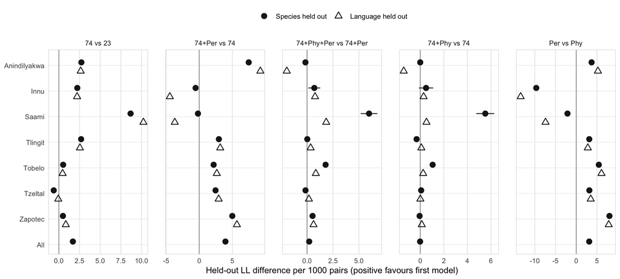

```r
fig_species <- cv %>%
  cross_join(bind_rows(lapply(names(contrasts), function(cn)
    tibble(contrast = cn, a = contrasts[[cn]][1], b = contrasts[[cn]][2])))) %>%
  filter(model == a | model == b) %>%
  mutate(sign = if_else(model == a, 1, -1)) %>%
  group_by(language, contrast, rep) %>%
  summarise(diff = 1000 * sum(sign * ll) / first(n_pairs), .groups = "drop") %>%
  group_by(language, contrast) %>%
  summarise(mean = mean(diff), sd = sd(diff), .groups = "drop") %>%
  mutate(method = "Species held out")

fig_lolo <- lolo_tab %>%
  filter(score == "Recalibrated intercept") %>%
  transmute(language = as.character(held_out), contrast = as.character(contrast),
            mean = diff_per_1000, sd = NA_real_,
            method = "Language held out")

fig_levels <- rev(lang_order)
fig_data <- bind_rows(fig_species, fig_lolo) %>%
  mutate(contrast = factor(contrast, contrast_order),
         method = factor(method, c("Species held out", "Language held out")),
         # offset the LOLO marker below the species-held-out one
         y = match(language, fig_levels) +
           if_else(method == "Language held out", -0.22, 0.12))

p <- ggplot(fig_data, aes(x = mean, y = y)) +
  geom_vline(xintercept = 0, colour = "grey60", linewidth = 0.4) +
  geom_errorbarh(aes(xmin = mean - sd, xmax = mean + sd),
                 data = filter(fig_data, !is.na(sd)),
                 height = 0, colour = "grey20", linewidth = 0.5) +
  geom_point(aes(shape = method), size = 2.4, colour = "grey10",
             fill = "grey10", stroke = 0.7) +
  scale_shape_manual(values = c("Species held out" = 21,
                                "Language held out" = 2), name = NULL) +
  scale_y_continuous(breaks = seq_along(fig_levels), labels = fig_levels,
                     expand = expansion(add = 0.5)) +
  facet_wrap(~ contrast, nrow = 1, scales = "free_x") +
  labs(x = "Held-out LL difference per 1000 pairs (positive favours first model)",
       y = NULL) +
  theme_minimal(base_size = 10) +
  theme(legend.position = "top",
        panel.spacing.x = unit(1.4, "lines"),
        panel.border = element_rect(colour = "grey85", fill = NA),
        panel.grid.major.y = element_line(colour = "grey95"),
        panel.grid.minor = element_blank(),
        panel.grid.major.x = element_line(colour = "grey92"))
p
```

```r
ggsave(file.path(out_dir, "cv_contrasts.png"), p, width = 10, height = 4.5,
       dpi = 300, bg = "white")
```

# Limitations

- **Leave-one-language-out has only 7 languages, so its inferential power is limited.** A two-sided sign test can’t reach p < .05 unless all 7 languages agree, and even then p ≈ .016. If 6 of 7 agree, p ≈ .125. A paired t-test across languages has 6 df and low power. The 7 languages are also a convenience sample, not a random sample of the world’s folk taxonomies: they come from different ethnographers and are clustered by region. So “the relationship transfers to a new language” means “to languages like these”. The LOLO results are therefore best read as effect sizes, language by language, rather than as a test.
- **The species-held-out CV isn’t a significance test either.** The SD across splits shows how much the result depends on the random fold assignment, not the sampling uncertainty in the comparison. Pairs still share species and categories, so no simple standard error applies.
- **What the CV does provide** is a fairer point estimate of how well each model predicts unseen species than in-sample BIC, which treats about 70k dependent pairs as independent. Valid p-values for “does this measure add anything?” and “is 1974 better than 2023?” need the permutation tests and MRQAP described in `README_analysis_plan.md` §2, which are not implemented here.